# Babylab data - exploration

To do

- ajouter topo sur la jointure avec autres bases sepages
- once discussed all the data cleaning steps add to process
- then correlate 24 month scores to 24 month neuro scores (see notes)

Since last time:

- 34 new obs
- 19 new individuals
- 2 new tasks
- new scores

To discuss

- age outlier 36m
- task 2 missing not all at the beginning of sepages
- should we use the following vars for cleaning and if yes how
  - sig_qual
  - n_trial
- mean look times: we talked about describing the low mean looking times. **What is low? What to describe?**
- how do we use it for cleaning?
- should it also be used only for cleaning?
- validate the final choice of indicators
- Confirm we exclude indicators with quality 1 | 2 except map
- confirm that corr between param1 and param2 also just used to clean (they aree all > 0.9)
- mean map compare uniquement aux enfants sepages ou d’autres enfants?
- what are the units in the novelty score?
- 16 missing task 4, excluded for now
- which to choose between number of saccades and number of fixations
- which to choose between pct eyes and pct mouth?
- how to use the repeated measures?
- talk about age effect (had seen in ariane’s notes that there shouldn’t be one… not what data shows)

# 1 Intro

## 1.1 Context

One of the goals of sepages is to analyse the link between exposure to endocrine disruptors during pregnancy and the infant’s neurological development. One of the experiments to quantify neurologic development was to perform eye tracking experiments at Grenoble’s LPNC **BabyLab**. Sepages infants were subject to several tasks and were seen up to 3 times: at 5 months, 12 months, 24 months.

Here are the descriptive stats on the babylab dataset **DataFile_030220_anonym_id.csv**.

First we present the different tasks and scores. Then we briefly describe the population. Finally we decide on a subseletcion of scores for final analysis.

## 1.2 Eye tracking

Eye movement is measured by X-Y coordinates continuously. Eye movement consists of a sequence of **saccades** (movement) and **fixations** (non movements). Using the eye tracker several tasks are performed for which various scores were computed. Four tasks were performed for this study:

- **scene perception**
- **face perception and recognition**
- **saccades to target**
- **smooth pursuit**

### 1.2.1 Scene perception

An image is shown to the baby for five seconds each. The experiment is repeated six times.

We are interested in looking at what part of the image the infant looks at.

The scores available for this task are

1. The number of saccades during the task (`n_sacc_1`)
2. The values of a and b in the equation v = b*d^a (`param1_1` & `param2_1`)
3. The mean number of fixations over the six images (`n_fix_mean_1`)
4. The mean total time spent looking at the image (`look_t_mean_1`)
5. The mean duration of one fixation (`dur_fix_mean_1`)
6. A score to compute if the child looks at the same place of the image or not as the other children (`map_mean_1`)

### 1.2.2 Face perception and recognition

Two pictures of the same human face are simultaneously shown to the baby for 10 seconds. Then, one picture is replaced by a new one (the faces have different levels of attractiveness) and the two different pictures are shown to the baby for 10 seconds. The experiment is repeated four times.

We are interested in measuring the reaction to novelty: the baby should preferentially look at the new face.

But problem here: the duration of exposure to the different pictures is too long. **WHY???**

The scores available for this task are

1. The number of saccades during the task (`n_sacc_2`)
2. The values of a and b in the equation v = b*d^a (`param1_2` & `param2_2`)
3. The mean number of fixations over the six images (`n_fix_mean_2`)
4. The mean total time spent looking at the image (`look_t_mean_2`)
5. The mean duration of one fixation (`dur_fix_mean_2`)
6. The reaction to novel face over four tests (`novelty_2`) **need more info on formula**
7. Reaction time (`reaction_time_2`) **need more info on formula**
8. Percent time spent looking at eyes (`pct_eyes_2`)
9. Percent time spent looking at mouth (`pct_mouth_2`)

### 1.2.3 Saccades to target

The scores available for this task are

1. Reaction time (`reaction_time_3`) **need more info on formula**
2. Mean length of the first saccade to target (`dist_3`)

### 1.2.4 Smooth pursuit

The scores available for this task are

1. Reaction time (`reaction_time_4`) **need more info on formula**

# 2 Population description

## 2.1 Individuals

- N unique individuals = 196
- Sex:

|  | n | % | val% |
| --- | --- | --- | --- |
| F | 88 | 44.9 | 44.9 |
| M | 108 | 55.1 | 55.1 |

As a reminder in sepages: 251 boys (53%) and 218 girls (47%).

- Birth dates:

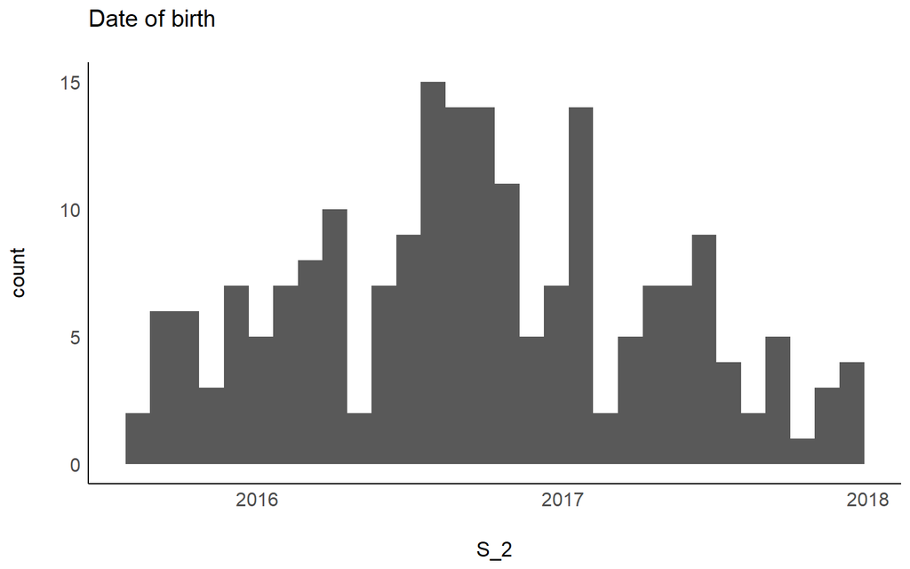

## 2.2 Experiments

- N experiments: 264

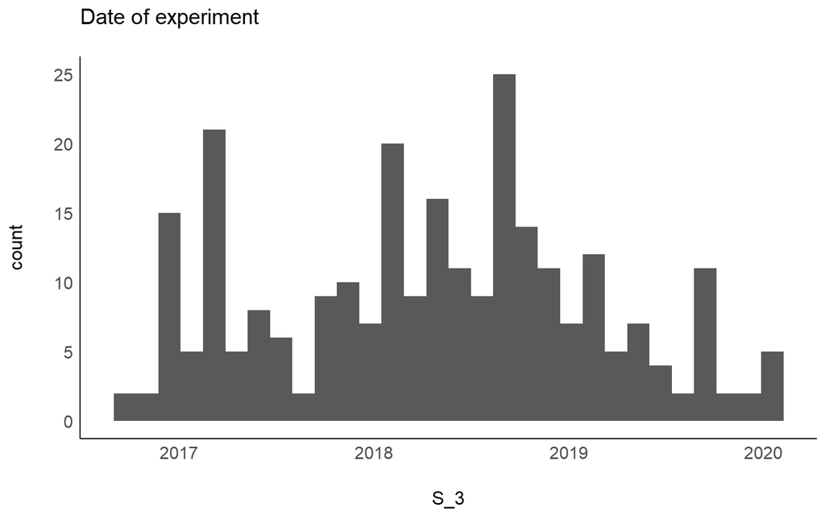

9 obs missing data for the face perception experiment

Dates for these 9 exp:

```
## [1] "2016-09-20" "2016-09-26" "2016-10-27" "2016-11-18" "2016-12-07"
## [6] "2016-12-15" "2017-01-10" "2017-06-01" "2019-02-27"
```

10 first dates:

```
##  [1] "2016-09-20" "2016-09-26" "2016-10-27" "2016-11-18" "2016-12-07"
##  [6] "2016-12-07" "2016-12-08" "2016-12-08" "2016-12-08" "2016-12-09"
```

OK for the first 5, but not all at the beginning, why?

## 2.3 Age at experiment

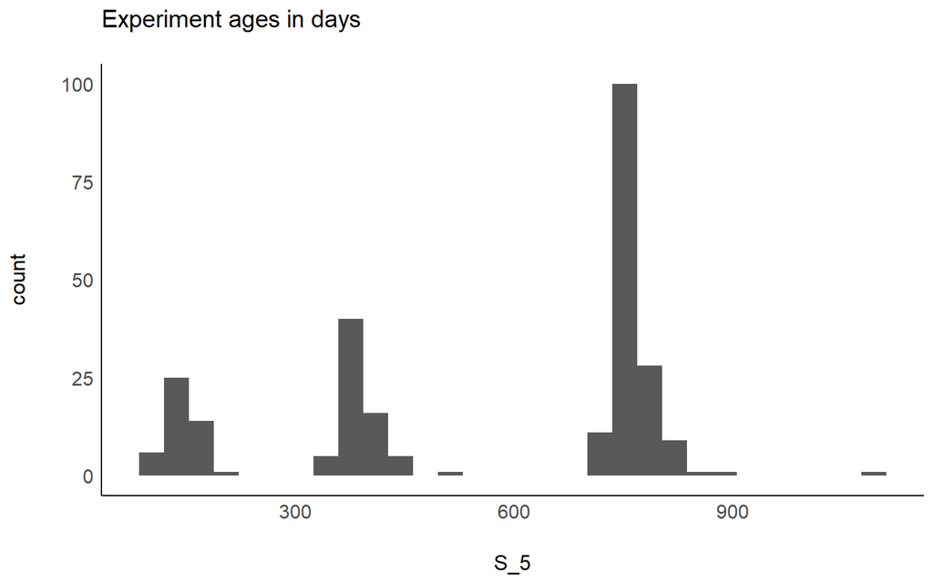

Older outlier:

```
## # A tibble: 1 x 4
##   date_birth date_exp   age_cat age_days
##   <date>     <date>       <dbl>    <dbl>
## 1 2016-01-07 2019-01-08      24     1097
```

True age in months = 1097 / 30.4 = 36…

**Error? Exclude?**

Three groups of age: 5 months, 12 months and 24 months with a majority of 24 months. Categorical age var:

|  | n | % | val% |
| --- | --- | --- | --- |
| 5 | 46 | 17.4 | 17.4 |
| 12 | 67 | 25.4 | 25.4 |
| 24 | 151 | 57.2 | 57.2 |

## 2.4 Repeated measures

Number of repeated data:

- 134 children with 1 experiment
- 56 children with 2 experiments
- 6 children with 3 experiments

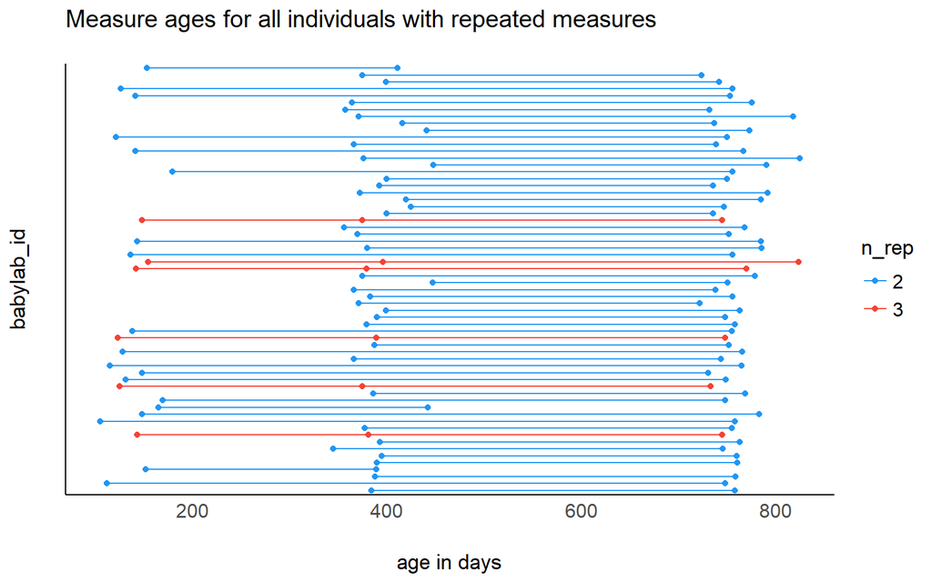

# 3 Eye tracker scores

First we do some univariate statistics on the scores then we look at relations between them to see if we can/need to exclude some from further analysis.

## 3.1 Description

Data Frame Summary

**scores**  
**Dimensions**: 264 x 22  
**Duplicates**: 0

| **No** | **Variable** | **Stats / Values** | **Freqs (% of Valid)** | **Graph** | **Missing** |
| --- | --- | --- | --- | --- | --- |
| 1 | babylab_id [character] | 1. 127 2. 147 3. 170 4. 20 5. 26 6. 43 7. 101 8. 103 9. 105 10. 106 [ 186 others ] | 3 ( 1.1% ) 3 ( 1.1% ) 3 ( 1.1% ) 3 ( 1.1% ) 3 ( 1.1% ) 3 ( 1.1% ) 2 ( 0.8% ) 2 ( 0.8% ) 2 ( 0.8% ) 2 ( 0.8% ) 238 ( 90.1% ) |  | 0 (0%) |
| 2 | S_4 [numeric] | Mean (sd) : 17.6 (7.7) min < med < max: 5 < 24 < 24 IQR (CV) : 12 (0.4) | 5 : 46 ( 17.4% ) 12 : 67 ( 25.4% ) 24 : 151 ( 57.2% ) |  | 0 (0%) |
| 3 | S_5 [numeric] | Mean (sd) : 560.5 (249.6) min < med < max: 105 < 737.5 < 1097 IQR (CV) : 383.2 (0.4) | 149 distinct values |  | 0 (0%) |
| 4 | n_sacc_1 [numeric] | Mean (sd) : 82 (15.6) min < med < max: 38 < 81.5 < 170 IQR (CV) : 17.2 (0.2) | 62 distinct values |  | 0 (0%) |
| 5 | param1_1 [numeric] | Mean (sd) : 0.7 (0.1) min < med < max: 0.6 < 0.7 < 0.9 IQR (CV) : 0.1 (0.1) | 262 distinct values |  | 0 (0%) |
| 6 | param2_1 [numeric] | Mean (sd) : 0.7 (0.2) min < med < max: 0.2 < 0.7 < 1.4 IQR (CV) : 0.2 (0.3) | 264 distinct values |  | 0 (0%) |
| 7 | n_fix_mean_1 [numeric] | Mean (sd) : 9.1 (2.4) min < med < max: 2.5 < 9.3 < 14.5 IQR (CV) : 3.3 (0.3) | 73 distinct values |  | 0 (0%) |
| 8 | dur_fix_mean_1 [numeric] | Mean (sd) : 370 (60.1) min < med < max: 272 < 358 < 697 IQR (CV) : 77 (0.2) | 151 distinct values |  | 0 (0%) |
| 9 | map_mean_1 [numeric] | Mean (sd) : 0.1 (0) min < med < max: 0 < 0.1 < 0.1 IQR (CV) : 0 (0.2) | 264 distinct values |  | 0 (0%) |
| 10 | n_sacc_2 [numeric] | Mean (sd) : 97.8 (15.9) min < med < max: 46 < 99 < 148 IQR (CV) : 20.5 (0.2) | 69 distinct values |  | 9 (3.41%) |
| 11 | param1_2 [numeric] | Mean (sd) : 0.7 (0.1) min < med < max: 0.5 < 0.7 < 0.9 IQR (CV) : 0.1 (0.1) | 254 distinct values |  | 9 (3.41%) |
| 12 | param2_2 [numeric] | Mean (sd) : 0.8 (0.2) min < med < max: 0.3 < 0.8 < 1.6 IQR (CV) : 0.3 (0.3) | 254 distinct values |  | 9 (3.41%) |
| 13 | n_fix_mean_2 [numeric] | Mean (sd) : 8.3 (2.3) min < med < max: 2 < 8.2 < 15.8 IQR (CV) : 2.9 (0.3) | 72 distinct values |  | 9 (3.41%) |
| 14 | dur_fix_mean_2 [numeric] | Mean (sd) : 382.8 (66.8) min < med < max: 222 < 372 < 607 IQR (CV) : 80.5 (0.2) | 149 distinct values |  | 9 (3.41%) |
| 15 | map_mean_2 [numeric] | Mean (sd) : 0.1 (0) min < med < max: 0 < 0.1 < 0.1 IQR (CV) : 0 (0.2) | 254 distinct values |  | 9 (3.41%) |
| 16 | novelty_2 [numeric] | Mean (sd) : 0.1 (0.2) min < med < max: -0.4 < 0.1 < 0.6 IQR (CV) : 0.2 (1.8) | 255 distinct values |  | 9 (3.41%) |
| 17 | reaction_time_2 [numeric] | Mean (sd) : 420.2 (84.8) min < med < max: 248 < 414.3 < 844 IQR (CV) : 104.8 (0.2) | 237 distinct values |  | 9 (3.41%) |
| 18 | pct_eyes_2 [numeric] | Mean (sd) : 0.7 (0.2) min < med < max: 0.1 < 0.7 < 1 IQR (CV) : 0.2 (0.3) | 255 distinct values |  | 9 (3.41%) |
| 19 | pct_mouth_2 [numeric] | Mean (sd) : 0.1 (0.2) min < med < max: 0 < 0.1 < 0.8 IQR (CV) : 0.2 (1.1) | 235 distinct values |  | 9 (3.41%) |
| 20 | reaction_time_3 [numeric] | Mean (sd) : 291.4 (54.1) min < med < max: 182 < 286.9 < 484 IQR (CV) : 70.5 (0.2) | 214 distinct values |  | 4 (1.52%) |
| 21 | dist_3 [numeric] | Mean (sd) : 187 (28) min < med < max: 128.3 < 185.4 < 345 IQR (CV) : 28.1 (0.1) | 260 distinct values |  | 4 (1.52%) |
| 22 | reaction_time_4 [numeric] | Mean (sd) : 330 (88.3) min < med < max: 96 < 313 < 750 IQR (CV) : 89 (0.3) | 171 distinct values |  | 16 (6.06%) |

Also 16 missing task 4, will exclude for now.

## 3.2 Score vs age

I had this in my notes (I think it came from the meeting with Ariane). Seems to imply no need to take age into account.

> We should not stratify the analysis on age because few babies for some age groups. If really necessary: normalization, a posteriori, on the residuals. We will start by looking at the effect of age on these measures model for longitudinal data might be an option or focusing only on the 2 years but would be nice to have all the measurements.

> Remarks on baby-adult differences:  
> * Babies tend to look at pictures for shorter periods than adults;  
> * Centrality bias stronger for adults than babies (not considered in the following experiments);  
> * Adults always start to look to the left of the picture, whatever it is a motion or a portrait. Babies always start to look to the left of the picture if it is a motion but start from right or left if it is a portrait;  
> * When a moving target must be followed, babies tend to be late while adults may be a bit in advance. ^

> Age effect more or less strong according to the kind of pictures. Here, babies are homogeneous: we will quickly notice if a baby does not behave as the others.

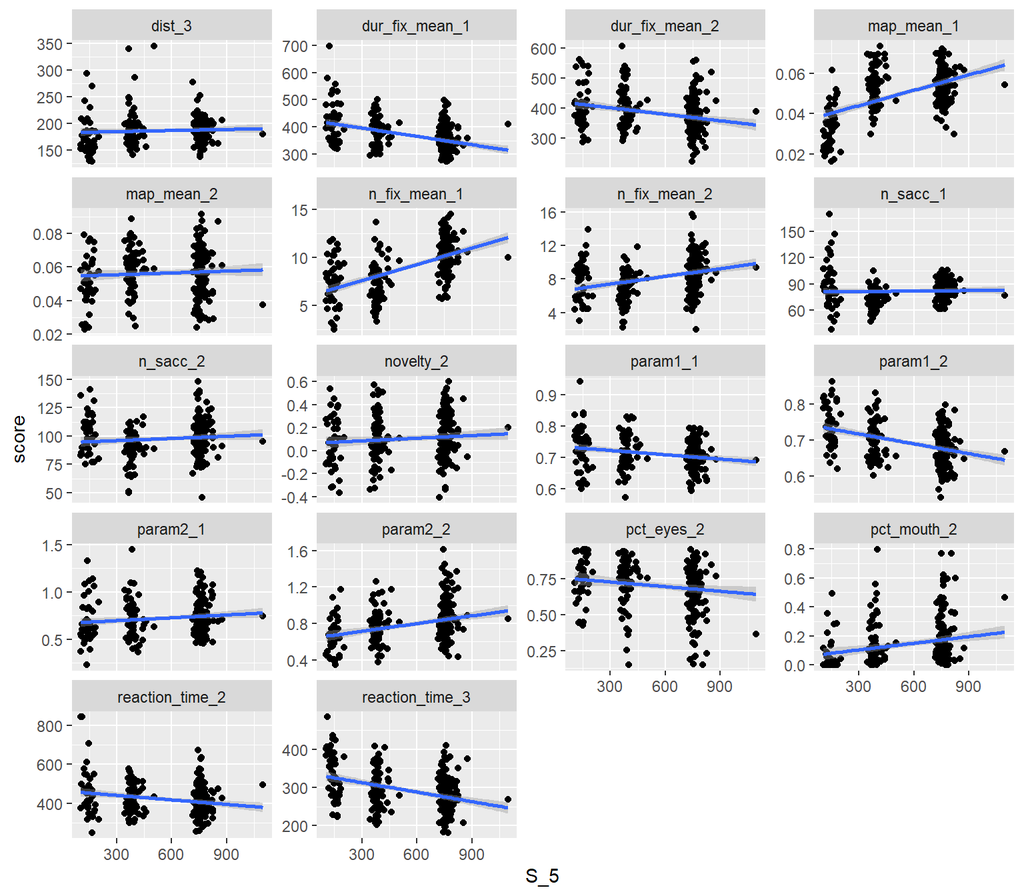

- There seems to be a strong age effect hance I stratify the following descriptive analyses by group age

## 3.3 Correlation between scores

Here we look at how the scores are correlated. We will focus on scores that are supposed to measure the same trait accross different tasks (eg reaction time at task 2 and 3) and scores that are mathematically linked (eg number of saccades and number of fixations).

### 3.3.1 Absolute(correlations) between all scores

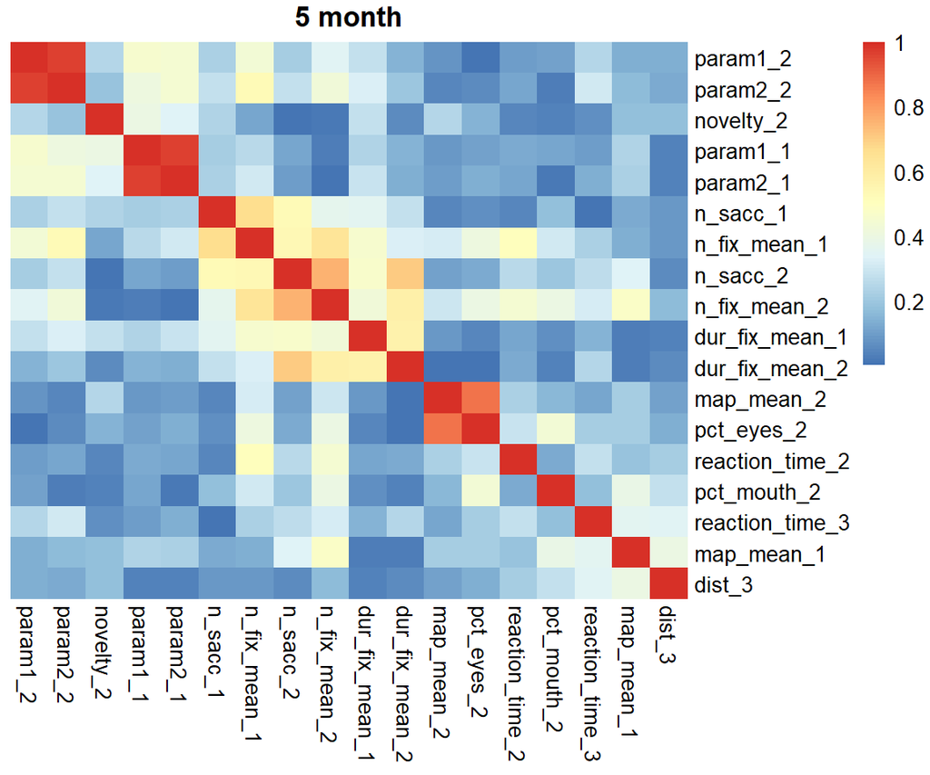

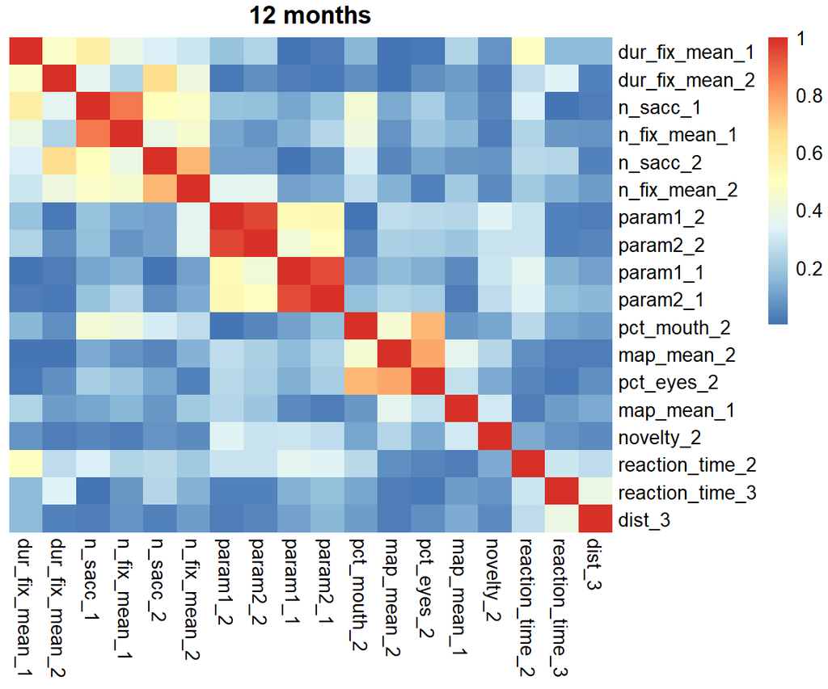

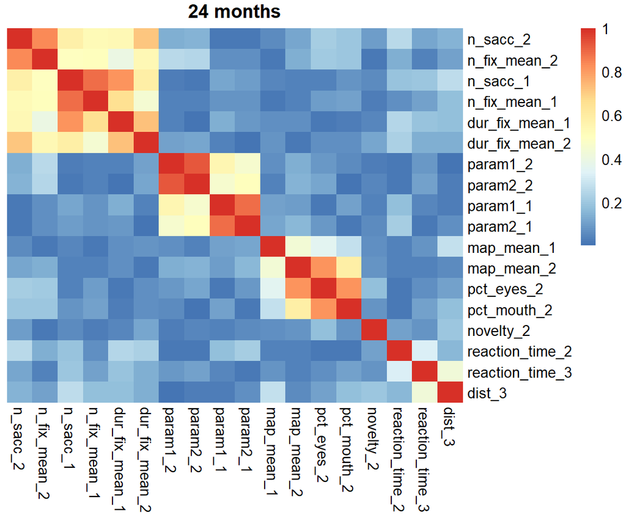

- all scores that measure saccade/fixations are grouped
- the saccade equation parameters param1 and param2 highly correlated
- the task 2 qualitative indicators pct_eyes, pct_mouth and map_mean correlated
- correlations increase with age

### 3.3.2 Correlation between tasks

Correlations on same scores/different tasks:

| rowname | score | cor5 | cor12 | cor24 |
| --- | --- | --- | --- | --- |
| n_fix_mean_1 | n_fix_mean_2 | 0.64 | 0.45 | 0.50 |
| dur_fix_mean_1 | dur_fix_mean_2 | 0.57 | 0.47 | 0.73 |
| n_sacc_1 | n_sacc_2 | 0.53 | 0.50 | 0.58 |
| param1_1 | param1_2 | 0.45 | 0.53 | 0.55 |
| param2_1 | param2_2 | 0.44 | 0.49 | 0.51 |
| reaction_time_2 | reaction_time_3 | 0.28 | 0.29 | 0.32 |
| map_mean_1 | map_mean_2 | 0.21 | 0.36 | 0.43 |

- The saccades/fixation parameters rather correlated accross task
- Map mean and reaction time not so much
- Overall increase of correlation with age

### 3.3.3 Variable PCA

PCA performed on complete observations

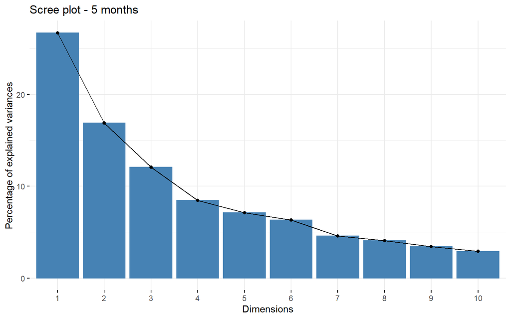

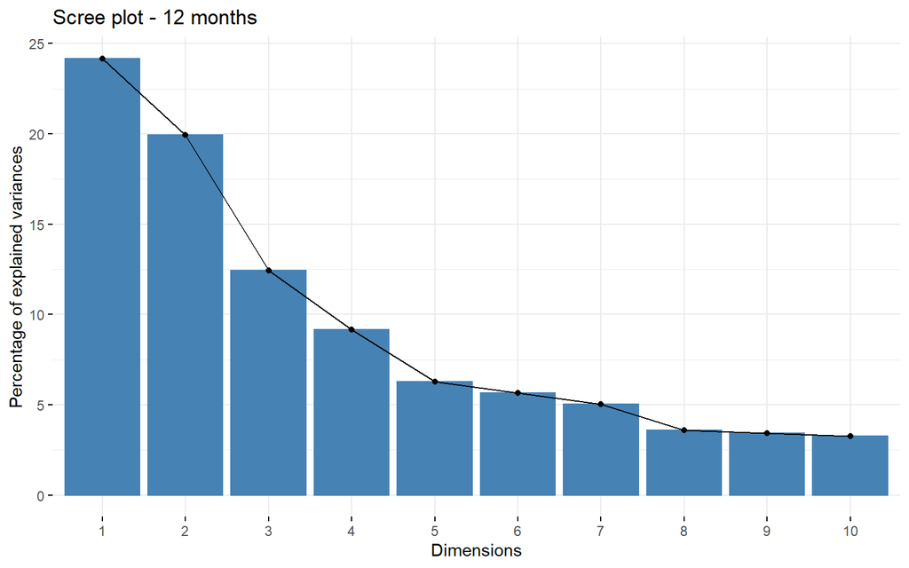

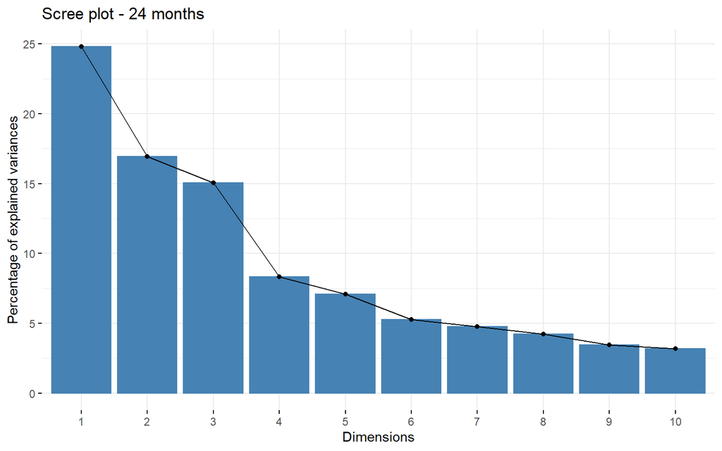

Main contributors to the first 3 PCs

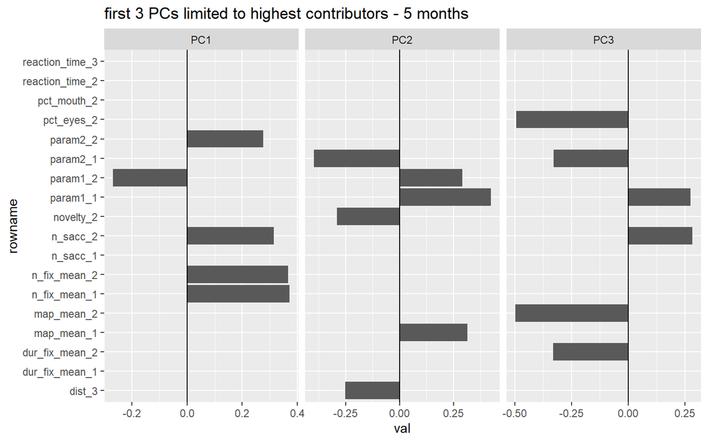

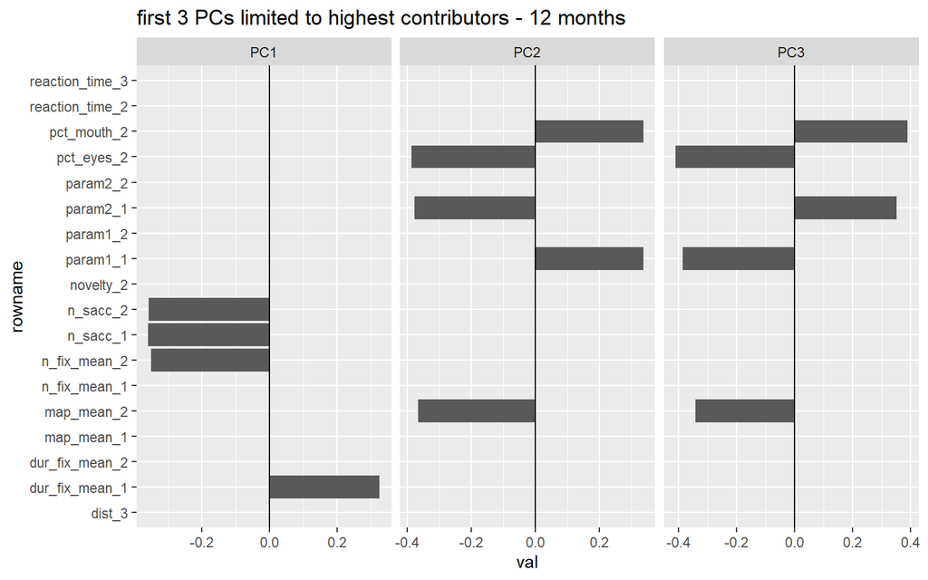

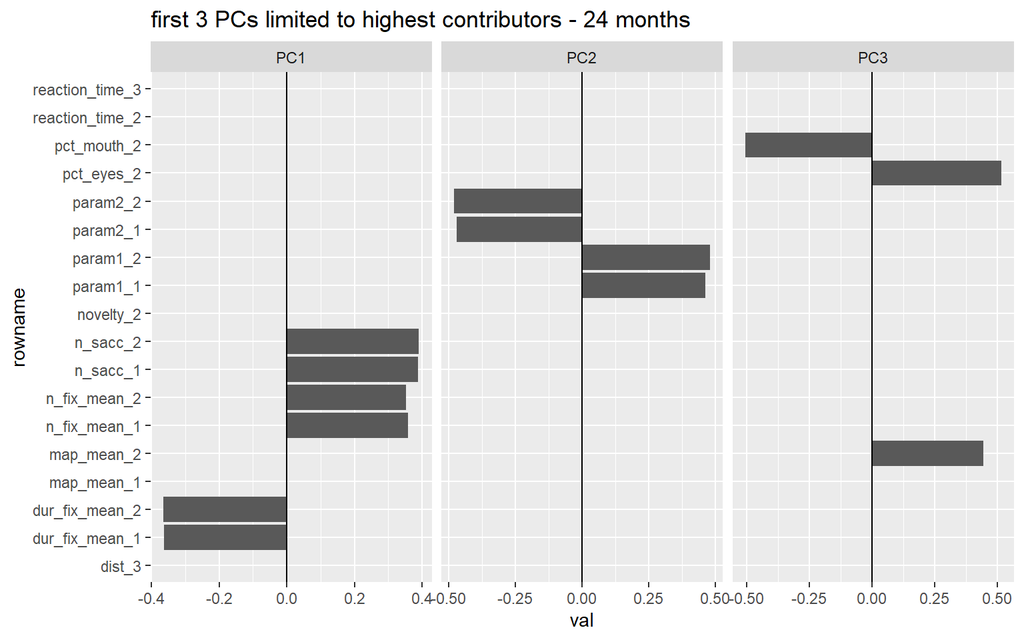

Similar conclusions to previous

(interprétations à la louche)

- PC1 mainly variables to do with saccades/fixation: number, time, etc
- PC2 mainly saccade equation parameters (at least for 12 and especially 24 months)
- PC3 mainly qualitative indicators eyes/mouth, map etc
- Varaiable grouping getseems to get more clear with age

## 3.4 Conclusions

- Some variables are highly correlated within task, maybe we should choose between them for further analyses
  - `pct_eyes` & `pct_mouth` : directly linked, if you don’t look at the eyes you look at the mouth, hence the high correlation
  - `n_sacc` & `n_fix_mean`: directly linked, you have one fixation between two saccades so the more you have saccades the more you have fixations, the more you have fixations hence the high correlation
- Accross task the scores are somewhat correlated, may be interesting to model as latent variable in the event of a multivariate model
- Overall groups of scores seem to be
  - n_sacc, n_fix, length_fix
  - param1, param2
  - pct eyes, pct mouth, mean map
  - novelty
  - reaction time
  - dist

# 4 Repeated measures

## 4.1 Correlations

Correlation for each score between each period (5 months, 12 months and 24 months):

| task | cor_5_12 | n_1 | cor_12_24 | n_2 | cor_5_24 | n_3 |
| --- | --- | --- | --- | --- | --- | --- |
| dur_fix_mean_1 | 0.64 | 9 | 0.65 | 43 | 0.08 | 22 |
| pct_mouth_2 | -0.30 | 6 | 0.57 | 41 | 0.40 | 19 |
| pct_eyes_2 | 0.50 | 6 | 0.55 | 41 | 0.04 | 19 |
| reaction_time_3 | 0.56 | 8 | 0.49 | 41 | 0.35 | 20 |
| dur_fix_mean_2 | 0.63 | 6 | 0.46 | 41 | 0.63 | 19 |
| n_sacc_1 | 0.61 | 9 | 0.44 | 43 | 0.10 | 22 |
| n_sacc_2 | 0.57 | 6 | 0.42 | 41 | 0.24 | 19 |
| map_mean_2 | 0.95 | 6 | 0.40 | 41 | 0.14 | 19 |
| n_fix_mean_2 | 0.74 | 6 | 0.40 | 41 | 0.31 | 19 |
| param1_1 | 0.10 | 9 | 0.39 | 43 | 0.33 | 22 |
| novelty_2 | -0.03 | 6 | 0.33 | 41 | -0.11 | 19 |
| param2_1 | 0.08 | 9 | 0.31 | 43 | 0.18 | 22 |
| map_mean_1 | -0.18 | 9 | 0.28 | 43 | 0.13 | 22 |
| n_fix_mean_1 | 0.55 | 9 | 0.26 | 43 | 0.42 | 22 |
| param2_2 | 0.32 | 6 | 0.22 | 41 | 0.23 | 19 |
| dist_3 | 0.28 | 8 | 0.11 | 41 | 0.06 | 20 |
| param1_2 | 0.07 | 6 | 0.11 | 41 | 0.21 | 19 |
| reaction_time_2 | 0.37 | 6 | 0.10 | 41 | 0.15 | 19 |

## 4.2 Visualisation

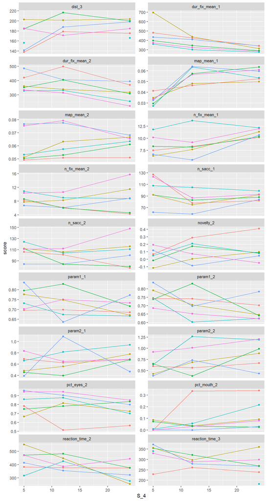

## 4.3 Conclusions

Not sure yet what we can do with the repeated measures.

# 5 Conclusions

- Explain the final variables that were selected
- Which are correlated
- Which are correlated over time

Matthieu Rolland

2020-02-12